# Lab 4

Mario Perales

February 15 2016

*Source file* ⇒ Lab_4.Rmd

# Task

In order to produce the plot on page 159 of the textbook, we must first wrangle the data in the Data Table *BabyNames*. We want to **filter** out specific cases by the variable **name**. We also want to add up the number of babies with that name, regardless of gender. Wrangling the data in such a way will allow us have a Glyph ready Data Table.

The following *R* code produces that table:

```r
GlyphReadyForm <-
  BabyNames %>%
  filter(name == "Abraham" | name == "Franklin" | name == "Woodrow") %>%
  group_by(name, year) %>%
  summarise(total = sum(count))
```

Now, we simply plot this Glpyh ready table using the command given on page 161. This produces the following graph:

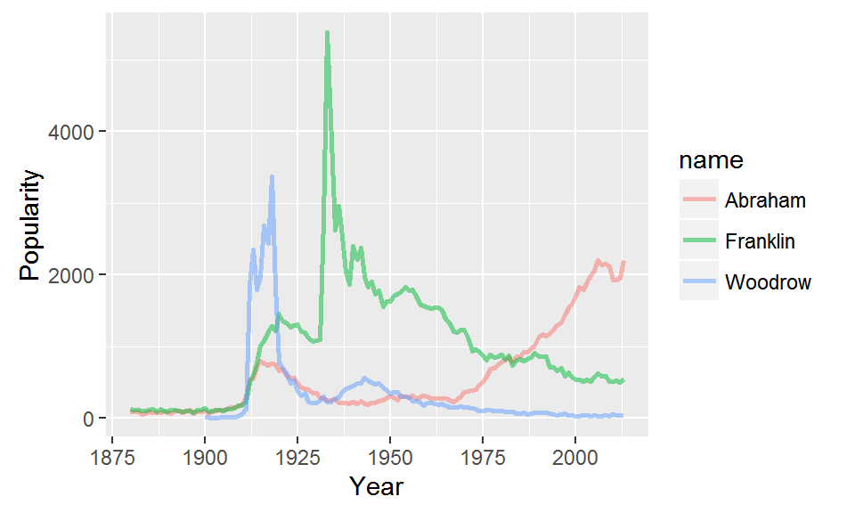

```r
GlyphReadyForm %>%
  ggplot(aes(x = year, y = total, group = name)) +
  geom_line( size = 1, alpha = 0.5, aes(color = name)) +
  ylab("Popularity") + xlab("Year")
```

Which is what we wanted!

It seems as if the names (which are of very popular US presidents) seems to have peaked during their presidencies. We verify this by using this *R* code to check what year the following names were the most popular.

```r
GlyphReadyForm %>%
  filter(name == "Franklin") %>%
  arrange(desc(total)) %>%
  head(1)
```

```
## Source: local data frame [1 x 3]
## Groups: name [1]
##
##       name  year total
##      (chr) (int) (int)
## 1 Franklin  1933  5385
```

```r
GlyphReadyForm %>%
  filter(name == "Woodrow") %>%
  arrange(desc(total)) %>%
  head(1)
```

```
## Source: local data frame [1 x 3]
## Groups: name [1]
##
##      name  year total
##     (chr) (int) (int)
## 1 Woodrow  1918  3372
```

```r
GlyphReadyForm %>%
  filter(name == "Abraham") %>%
  arrange(desc(total)) %>%
  head(1)
```

```
## Source: local data frame [1 x 3]
## Groups: name [1]
##
##      name  year total
##     (chr) (int) (int)
## 1 Abraham  2006  2203
```

The only outlier is *Abraham* but that is because we do not have data from his presidency.

# Miscellaneous

The project says we can try names of particular interest, thus I will examine my name. Again, we must produce the Glpyh ready table with the following *R* code:

```r
MyName <-
  BabyNames %>%
  filter(name == "Mario") %>%
  group_by(name, year) %>%
  summarise(total = sum(count))
```

And again we plot it:

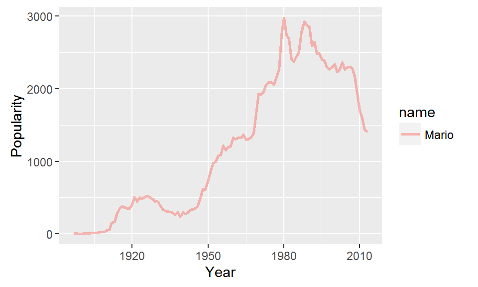

```r
MyName %>%
  ggplot(aes(x = year, y = total, group = name)) +
  geom_line( size = 1, alpha = 0.5, aes(color = name)) +
  ylab("Popularity") + xlab("Year")
```

To be more specific, my name was the most popular in (we use the same code as before):

```r
MyName %>%
  arrange(desc(total)) %>%
  head(1)
```

```
## Source: local data frame [1 x 3]
## Groups: name [1]
##
##    name  year total
##   (chr) (int) (int)
## 1 Mario  1980  2974
```

```r
MyName <-
  BabyNames %>%
  filter(name == "Aiden") %>%
  group_by(name, year) %>%
  summarise(total = sum(count))
```

And again we plot it:

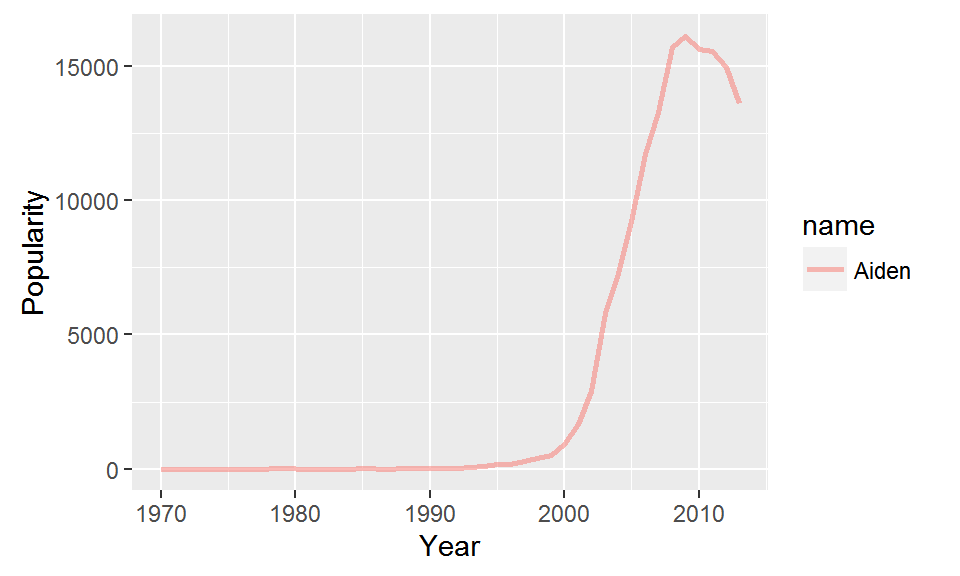

```r
MyName %>%
  ggplot(aes(x = year, y = total, group = name)) +
  geom_line( size = 1, alpha = 0.5, aes(color = name)) +
  ylab("Popularity") + xlab("Year")
```